# Rare Bird Forecast BETA

[figure not shown]

[figure not shown]

[figure not shown]

### Current and predicted vagrancy conditions

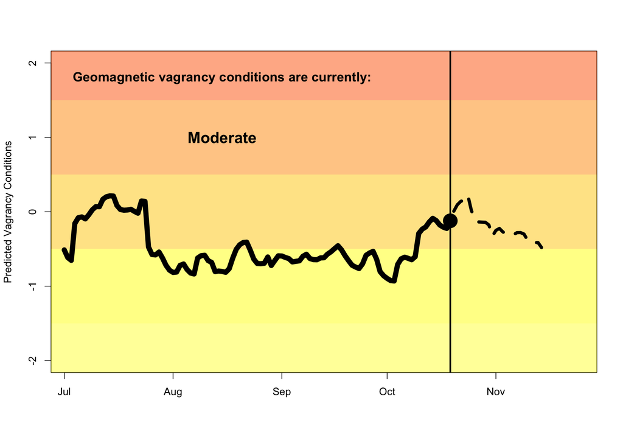

### Species Richness Trends

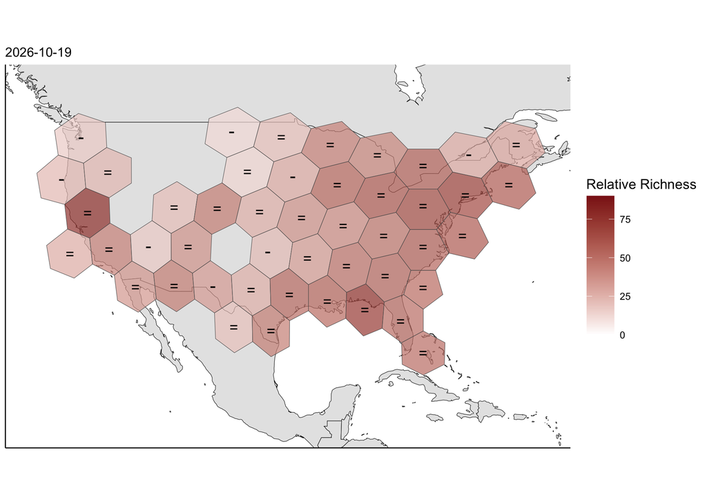

### Seasonality

The chance to see a rare bird is also determined by seasonality. Here, the relative number of banded species for this week is indicated by color scale, with +, - and = signs indicating where richness is increasing, decreasing, or staying about the same. Data from USGS Bird Banding Lab (BBL).

### Species Demographic Trends

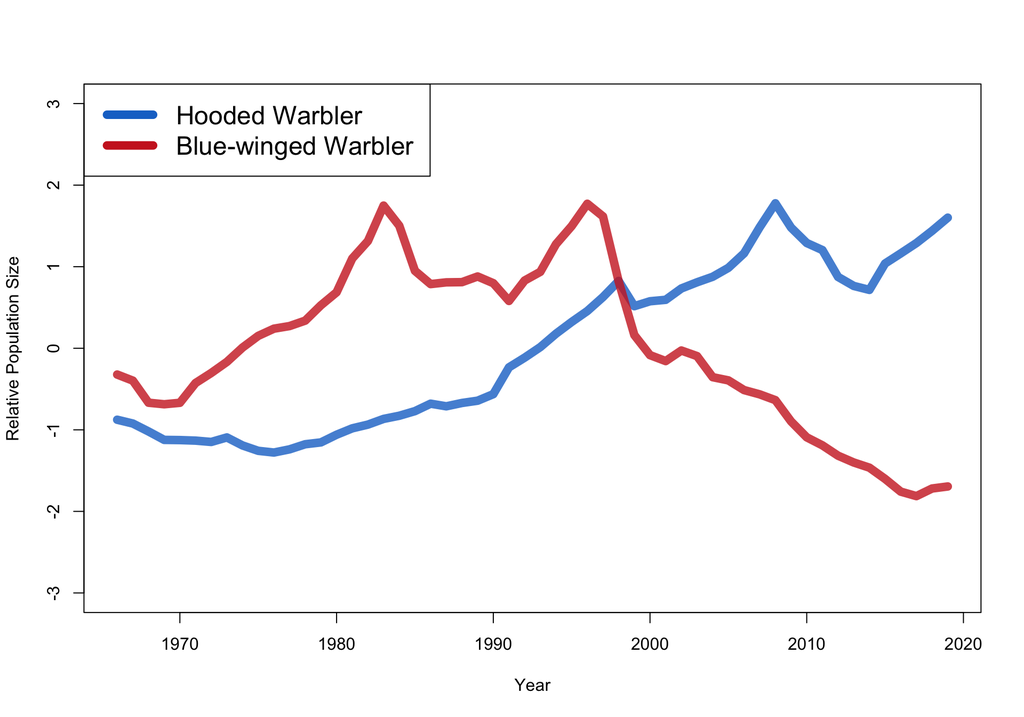

### Demographics

You are more likely to see a vagrant bird if the species is doing well demographically. Unfortunately, many bird species are in decline. But some species are doing well! Above shows the population trajectories for an increasing and decreasing species (updated daily). Data from USGS Breeding Bird Survey (BBS).

### Vagrancy Conditions

[interactive chart not shown]

Current vagrancy conditions

### Geomagnetic Disturbance

[interactive chart not shown]

Current magnetic field distortion

### Solar Activity

[interactive chart not shown]

Current solar activity conditions

### About

This dashboard is designed to be used as a tool for US birders and twitchers to evaluate the likelihood of seeing a rare bird. This tool integrates three known factors influencing vagrancy - current space weather conditions, seasonality, and demography - to predict the likelihood of seeing a rare bird. Please send questions/comments/suggestions to rarebirdforecast@gmail.com

[figure not shown]